# Note_kGaussian

Tran Le

2022-04-03

# 1 Introduction

This is the note that I use for learning about the EM algorithm. Other sections (EM introduction, R codes, (more detailed E and M step establish) Em for mixtures of $k=2$ Gaussian distribution in 1D and 2D) could be found from [[here](https://tranktle.github.io/portfolio/2022/03/31/EM-Mixture-Gaussian.html)].

# 2 Mixtures of $k\geq 2$ fixed number of Gaussian with unknown means and variances

We now consider the case of $k\geq$ mixing Normal distribution with unknown parameters in $1$ dimension.

Let’s $Y_i, i=\overline{1,n}$ are observed data gotten from mixture of $k$ Normal distribution with unknown parameters in 1 dimension space. Also, we don’t know about the distribution to which each data point belongs.

$$\begin{align}
f(y) &= \sum_{j=1}^k p_j f_j(y|\mu_j, \sigma_j^2), \text{ where } \sum_{j=1}^k p_j=1\\
&\quad f_j \equiv N(\mu_j, \sigma_j^2), \text{ where } \mu_j, \sigma_j^2 \text{ unknown }
\end{align}$$

We want to use EM algorithm to estimate $\boldsymbol{\theta}= (\boldsymbol{p}=(p_1, ..., p_k), \mu_j, \sigma_j^2, \forall j=\overline{1,k})$

Let $U_i$ is the label of the distribution that the data point $Y_i$ belongs to. We have

$$f(y_i) = f(y_i, u_i, \boldsymbol{p})= \prod_{j=1}^k [p_jf_j(y_i)]^{I(u_i=j)}$$

## 2.1 E step

We want to compute the $Q$ function

$$\begin{align}
Q(\boldsymbol{\theta}|\boldsymbol{\theta}^{(s)} ) &= E_{Y_{miss}}\left[ln\left(f(Y_{obs}, Y_{miss}|\boldsymbol{\theta})\right) | Y_{obs}, \boldsymbol{\theta}^{(s)} \right]\\
&= E_{U}\left[ln\left(f(\boldsymbol{Y},\boldsymbol{U})|\boldsymbol{\theta})\right) | Y, \boldsymbol{\theta}^{(s)} \right]
\end{align}$$

- The complete data likelihood

$$\begin{align}
f(\boldsymbol{Y},\boldsymbol{U}|\boldsymbol{\theta})&= \prod_{i=1}^n f(y_i) = \prod_{i=1}^n \prod_{j=1}^k [p_jf_j(y_i)]^{I(u_i=j)}
\end{align}$$

- The complete data log-likelihood:

$$\begin{align}
ln(f(\boldsymbol{Y},\boldsymbol{U}|\boldsymbol{\theta}))&= \sum_{i=1}^n \sum_{j=1}^k I(U_i=j) ln(p_jf_j(y_i))\\
&= \sum_{i=1}^n \sum_{j=1}^k I(U_i=j) [ln(p_j) + ln(f_j)(y_i)]
\end{align}$$

- The $Q$ function

$$\begin{align*}
Q(\boldsymbol{\theta}|\boldsymbol{\theta}^{(s)}) &= E_{U}\left[ln\left(f(\boldsymbol{Y},\boldsymbol{U})|\boldsymbol{\theta})\right) | \boldsymbol{Y}, \boldsymbol{\theta}^{(s)} \right]\\
&= E_U\left[\sum_{i=1}^n \sum_{j=1}^k I(U_i=j) [ln(p_j) + ln(f_j)(y_i)]| \boldsymbol{Y}, \boldsymbol{\theta}^{(s)}\right]\\
&= \sum_{i=1}^n \sum_{j=1}^k ln(p_i) E_U(I(U_i=j|\boldsymbol{Y}, \boldsymbol{p}^{(s)}))\\
& \quad + \sum_{i=1}^n \sum_{j=1}^k ln(f_j(y_i)) E_U(I(U_i=j|\boldsymbol{Y}, \boldsymbol{p}^{(s)}))\\
\end{align*}$$

Put

$$\pi_{ij}^{(s)}:= E_U(I(U_i=j|\boldsymbol{Y}, \boldsymbol{p}^{(s)})) = P(U_i=j| \boldsymbol{Y}, \boldsymbol{p}^{(s)}))$$
We have that the posterior probability $\pi_{ij}^{(s)}$
$$\begin{align}
\pi_{ij}^{(s)} = P(U_i=j| \boldsymbol{Y}, \boldsymbol{p}^{(s)}) =
\frac{P(U_i=j, \boldsymbol{p}^{(s)})f_j(y_i)}{\sum_{l=1}^k P(U_i=l, \boldsymbol{p}_l^{(s)})f_l(y_i)} =
\frac{p_j^{(s)} f_j(y_i)}{\sum_{l=1}^k p_l^{(s)} f_l(y_i))}
\end{align}$$

- We have the Q function

$$\begin{align*}
Q(\boldsymbol{\theta}|\boldsymbol{\theta}^{(s)}) &= \sum_{i=1}^n \sum_{j=1}^k ln(p_j) \pi_{ij}^{(s)} + \sum_{i=1}^n \sum_{j=1}^k ln(f_j(y_i)) \pi_{ij}^{(s)}\\
&= \sum_{i=1}^n \sum_{j=1}^k \pi_{ij}^{(s)} ln(p_j)+ \\
& \quad +\sum_{i=1}^n \sum_{j=1}^k \pi_{ij}^{(s)} \left(-\frac{1}{2}ln(2\pi)-\frac{1}{2}ln(\sigma_j^2)-\frac{1}{2\sigma_j^2}(y_i-\mu_j)^2\right)
\end{align*}$$

## 2.2 M step

We now want to find $\boldsymbol{\theta}= (\boldsymbol{p}=(p_1, ..., p_k), \mu_j, \sigma_j^2, \forall j=\overline{1,k})$ that maximize the $Q(\boldsymbol{\theta}|\boldsymbol{\theta}^{(s)})$ function

- First, we want to find the $\hat{p}_j$

$$\frac{\partial Q}{\partial p_j} = \sum_{i=1}^n \pi_{ij} \frac{1}{p_j}$$

Setting $\frac{\partial Q}{\partial p_j} = 0$ would not help us finding $p_j$ because the constraint $\sum_{j=1}^k p_j = 1$. We construct the Lagrangian [^1] by adding Lagrange multiplier to the $Q$ function

$$Q(\boldsymbol{p}, \boldsymbol{p}^{(s)}) = \sum_{j=1}^k ln(p_i) \sum_{i=1}^n \pi_{ij}+ \lambda (1-\sum_{j=1}^k p_j)$$
Let’s $\frac{\partial Q}{ \partial p_j} = 0$, we have

$$\begin{equation}
\frac{\partial Q}{ \partial p_j} = \frac{1}{p_j} \sum_{i=1}^n \pi_{ij}-\lambda=0 \Rightarrow p_j = \frac{\sum_{i=1}^n \pi_{ij}}{\lambda}\tag{2.1}
\end{equation}$$

Let’s $\frac{\partial Q}{\partial \lambda}=0$, we have

$$\begin{align*}
\frac{\partial Q}{\partial \lambda}=0 &\Rightarrow 1-\sum_{j=1}^k p_j =0\\
& \Rightarrow 1- \sum_{j=1}^k \sum_{i=1}^n \frac{\pi_{ij}}{\lambda} = 0\\
& \Rightarrow \sum_{j=1}^k \sum_{i=1}^n \pi_{ij} = n
\end{align*}$$

Then substitute $\lambda=n$ back to (2.1), we have

$$\begin{equation}
\hat{p}_j = \frac{\sum_{i=1}^n\pi_{ij}^{(s)}}{n}
\end{equation}$$

- Find $\mu_j, \sigma_j^2, \forall j=\overline{1, k}$ that maximize $Q$.

Let’s derivative of $Q$ wrt. to $\mu_j$ equal 0, we have

$$\begin{align}
& \frac{\partial Q}{\partial \mu_j}= \sum_{i=1}^n \pi_{ij}^{(s)}\frac{1}{\sigma_j^2}(y_i-\mu_j)=\frac{1}{\sigma_j^2}\left[\sum_{i=1}^n y_i \pi_{ij}^{(s)}- \mu_j \sum_{i=1}^n \pi_{ij}^{(s)}\right]=0\\
& \Rightarrow \hat{\mu}_j = \frac{\sum_{i=1}^n y_i \pi_{ij}^{(s)}}{\sum_{i=1}^n \pi_{ij}^{(s)}}
\end{align}$$

Let’s derivative of $Q$ wrt. to $\sigma_j^2$ equal 0, we have
$$\begin{align}
&\frac{\partial Q}{\partial \sigma_j^2} = \sum_{i=1}^n \left(\frac{-1}{2\sigma_j^2} + \frac{(y_i-\mu_j)^2}{2\sigma_j^4}\right) \pi_{ij}^{(s)} = - \sum_{i=1}^n \pi_{ij}^n \pi_{ij}^{(s)} + \frac{\sum_{i=1}^n (y_i-\mu_j)^2 \pi_{ij}^{(s)}}{\sigma_j^2}=0\\
& \Rightarrow \hat{\sigma}_j^2 = \frac{\sum_{i=1}^n(y_i-\mu_j)^2 \pi_{ij}^{(s)}}{\sum_{i=1}^n \pi_{ij}^{(s)}}
\end{align}$$

## 2.3 Pseudo-code for estimating parameters

1. Set initial values: $\boldsymbol{p}= (p^{(0)}, p^{(1)}, ..., p^{(k-1)}, 1-p^{(0)}-...p^{(k-1)})$ and $\mu_j^{(0)}, \sigma_j^{2(0)}, \forall j=\overline{1, k}$
2. For each EM iteration step
1. Update posterior probability
   $$\pi_{ij}^{(s+1)} = \frac{p_j^{(s)} f_j(y_i)}{\sum_{l=1}^k p_l^{(s)} f_l(y_i))}$$
2. Update parameter estimations $p_j^{(s+1)}$, $\mu_j^{(s+1)}, \sigma_j^{(s+1)}$
   $$\begin{align*}
   p_j^{(s+1)}&= \frac{\sum_{i=1}^n\pi_{ij}^{(s)}}{n}\\
   \mu_j^{(s+1)} &= \frac{\sum_{i=1}^n y_i \pi_{ij}^{(s)}}{\sum_{i=1}^n \pi_{ij}^{(s)}} \\
   \sigma_j^{(s+1)} &= \frac{\sum_{i=1}^n(y_i-\mu_j)^2 \pi_{ij}^{(s)}}{\sum_{i=1}^n \pi_{ij}^{(s)}}
   \end{align*}$$
3. Stopping criteria for step (2.):
1. $\boldsymbol{\theta}$ stop changing: $\Vert \boldsymbol{\theta}^{(s+1)}-\boldsymbol{\theta}^{(s)}\Vert < \epsilon_1$.
2. log-likelihood stop changing: $|l(\boldsymbol{\theta^{(s+1)}})-l(\boldsymbol{\theta^{(s)}})|<\epsilon_2$

# 3 Mixture of Gaussian distribution in dimension $d$.

The proof is the same as with dimension = 1, except the variance matrix $\Sigma$ is used instead of the variance $\sigma^2$ and the formula for updating $\Sigma$ is

$$\begin{equation}
\Sigma_j =\frac{\sum_{i=1}^n \pi_{ij} (x_j^{(i)}-\mu_j)(x_j^{(i)}-\mu_j)^T}{\sum_{i=1}^n \pi_{ij}}
\end{equation}$$

# 4 Examples of EM clustering algorithm for Gaussian mixture models

## 4.1 Example 1: Three Gaussian distributions in 1D

In this example, we will explore how sensitive the EM is to the prechosen number of clusters. The true data is on the LHS of the Fig.(@ref(fig:EX3_data)) with the true parameters are

$$\begin{equation*}
\begin{cases}
p_1=0.5, p_2=0.2, p_3=0.3\\
Y_1\sim N(50, 3), Y_2 \sim N(80, 4), Y_3\sim N(85,3)
\end{cases}
\end{equation*}$$

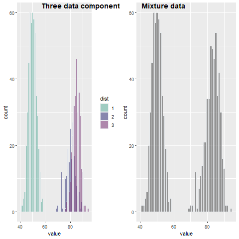

(#fig:EX3_data)Example of the case when it is hard to choose the correct number of clusters. The figure on the LHS presents the three true Gaussian components. The figure in the RHS represents the observed mixed data. From the mixed data, we hardly can notice that there are 3 clusters in the data.

Looking at the figure in the RHS of @ref(fig:EX3_data), we hardly can notice that there are three different components in that. Let’s see what happen if we choose the correct number of cluster and the wrong number of clusters to run the EM.

- When we choose the correct number of clusters, which is 3 in this example. Then we see that the EM works well with estimating the parameters and clustering with an error rate is $11.7\%$

| Parameters | $p_1$ | $\mu_1$ | $\sigma_1$ | $p_2$ | $\mu_2$ | $\sigma_2$ | $p_3$ | $\mu_3$ | $\sigma_3$ |
| --- | --- | --- | --- | --- | --- | --- | --- | --- | --- |
| True Values | 0.5 | 50 | 3 | 0.2 | 80 | 4 | 0.3 | 85 | 3 |
| Initial | 0.3 | 50 | 5.64 | 0.3 | 75 | 5.64 | 0.4 | 89 | 5.64 |
| Predicted | 0.5 | 49.9 | 3.07 | 0.173 | 80 | 4.25 | 0.327 | 84.6 | 3 |

| error | n | percent |
| --- | --- | --- |
| -1 | 100 | 0.100 |
| 0 | 883 | 0.883 |
| 1 | 17 | 0.017 |

- When we choose the wrong number of clusters, assume we choose 2, which is a reasonable number of clusters if we just look at the mixed data and have no information about the true number of clusters. Then we get the predicted values for the parameters

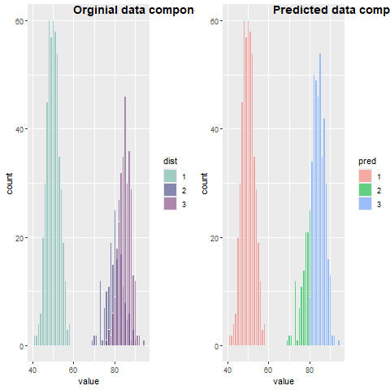

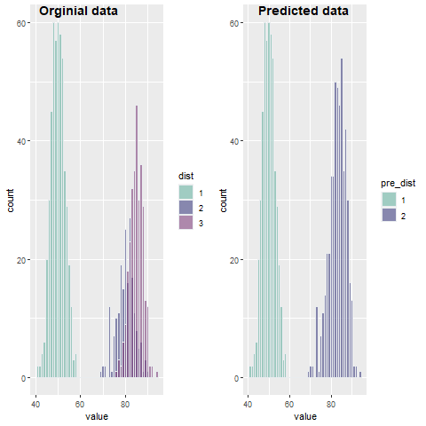

(#fig:EX3_correctk)LHS: Chosing a correct numeber of cluster, error rate= 11.7 percent. RHS: choose a wrong number of clusters, error rate = 30 percent.

| Parameter | $p_1$ | $\mu_1$ | $\sigma_1$ | $p_2$ | $\mu_2$ | $\sigma_2$ |
| --- | --- | --- | --- | --- | --- | --- |
| Predicted | 0.5 | 49.9 | 3.07 | 0.5 | 83 | 4.11 |

| Error | n | percent |
| --- | --- | --- |
| 0 | 700 | 0.7 |
| 1 | 300 | 0.3 |

# 5 Reference

McLachlan, G. J., & Krishnan, T. (2007). The EM algorithm and extensions (Vol. 382). John Wiley & Sons.

Ng, A. (2000). CS229 Lecture notes. CS229 Lecture notes, 1(1), 1-3.

[^1]: method of Lagrange multipliers is a strategy for finding the local maximum and minimum of a function $f$ subject to equality constraints $L(x, \lambda) = f(x) + \lambda g(x)$ with constraint g(x)=0